# Project 2

Moiya Josephs

3/10/2022

# General Overview

The goal of the assignment is to practice preparing various data sets and cleaning them using dplyr and tidyverse. We were tasked to choose three of the “wide” datasets identified in the Week 6 Discussion items. For each of the three chosen datasets:

I created a .CSV file that includes all of the information included in the data set. Use tidyr and dplyr as needed to tidy and transform your data. Perform the analysis requested in the discussion item.

# The Ramen rater, “THE BIG LIST,” 2021

## Overview

The first data set is called [Ramen Ratings](https://www.kaggle.com/residentmario/ramen-ratings) and it is recorded data of a ramen product review. Each ramen was rated on a 5-point scale to indicate its quality according to the reviewer. The data stays pretty current and has over 2400 lines of data.The recommended analysis suggested by my classmate was to:

1. Analyze the favorite flavor
2. Find the most popular brand
3. Find the most popular ramen style

### Read the data

```r
ramen_csv = "https://raw.githubusercontent.com/moiyajosephs/Data607-Project2/main/ramen-ratings.csv"
ramen = read.csv(ramen_csv,header=TRUE,sep=",")
summary(ramen)
```

```
##     Review..         Brand             Variety             Style
##  Min.   :   1.0   Length:2580        Length:2580        Length:2580
##  1st Qu.: 645.8   Class :character   Class :character   Class :character
##  Median :1290.5   Mode  :character   Mode  :character   Mode  :character
##  Mean   :1290.5
##  3rd Qu.:1935.2
##  Max.   :2580.0
##    Country             Stars             Top.Ten
##  Length:2580        Length:2580        Length:2580
##  Class :character   Class :character   Class :character
##  Mode  :character   Mode  :character   Mode  :character
##
##
##
```

```r
head(ramen) %>% kbl() %>%
  kable_styling()
```

| Review.. | Brand | Variety | Style | Country | Stars | Top.Ten |
| --- | --- | --- | --- | --- | --- | --- |
| 2580 | New Touch | T’s Restaurant Tantanmen | Cup | Japan | 3.75 |  |
| 2579 | Just Way | Noodles Spicy Hot Sesame Spicy Hot Sesame Guan-miao Noodles | Pack | Taiwan | 1 |  |
| 2578 | Nissin | Cup Noodles Chicken Vegetable | Cup | USA | 2.25 |  |
| 2577 | Wei Lih | GGE Ramen Snack Tomato Flavor | Pack | Taiwan | 2.75 |  |
| 2576 | Ching’s Secret | Singapore Curry | Pack | India | 3.75 |  |
| 2575 | Samyang Foods | Kimchi song Song Ramen | Pack | South Korea | 4.75 |  |

It looks like there are 2580 reviews in total with 7 columns. The review number/id the brand of ramen, variety, style, country and the rating. The last column Top.Ten looks as if it has no values, luckily there is a way to test if this is true.

```r
# Check if Top Ten is a missing column, if so remove it. Look what this value is supposed to be
topten_na <- sum(is.na(ramen$Top.Ten))
topten_na
```

```
## [1] 0
```

Interestingly enough the values are not counted as NA. I realized it is just an empty string.

```r
topten_empty <- sum(ramen$Top.Ten == "")
topten_empty
```

```
## [1] 2539
```

I was wrong before in assuming there were NA values. However I did note that the amount of empty strings does not equal the amount of rows available, that means there were values in the last column, though not many. To find which value it was I filtered

```r
topten_value <- ramen %>% select(Review..,Brand, Variety, Style, Country, Top.Ten) %>% filter(Top.Ten != "")
head(topten_value) %>% kbl() %>%
  kable_styling()
```

| Review.. | Brand | Variety | Style | Country | Top.Ten |
| --- | --- | --- | --- | --- | --- |
| 1964 | MAMA | Instant Noodles Coconut Milk Flavour | Pack | Myanmar | 2016 #10 |
| 1947 | Prima Taste | Singapore Laksa Wholegrain La Mian | Pack | Singapore | 2016 #1 |
| 1925 | Prima | Juzz’s Mee Creamy Chicken Flavour | Pack | Singapore | 2016 #8 |
| 1907 | Prima Taste | Singapore Curry Wholegrain La Mian | Pack | Singapore | 2016 #5 |
| 1828 | Tseng Noodles | Scallion With Sichuan Pepper Flavor | Pack | Taiwan | 2016 #9 |
| 1689 | Wugudaochang | Tomato Beef Brisket Flavor Purple Potato Noodle | Pack | China | 2016 #7 |

By filtering the data this way I can understand the point of the column. Now I understand that the column Top.Ten is indicating the rating the ramen got for being top ten best of that given year.

To go into further analysis I will change the empty strings to NA since R has nice functionality in how to deal with missing values. I will also remove the new line entries in some of the rows.

```r
ramen <- ramen %>% mutate(Top.Ten = replace(Top.Ten, Top.Ten== "", NA )) %>% mutate(Top.Ten = replace(Top.Ten, Top.Ten == "\n", NA ))
head(ramen) %>% kbl() %>%
  kable_styling()
```

| Review.. | Brand | Variety | Style | Country | Stars | Top.Ten |
| --- | --- | --- | --- | --- | --- | --- |
| 2580 | New Touch | T’s Restaurant Tantanmen | Cup | Japan | 3.75 | NA |
| 2579 | Just Way | Noodles Spicy Hot Sesame Spicy Hot Sesame Guan-miao Noodles | Pack | Taiwan | 1 | NA |
| 2578 | Nissin | Cup Noodles Chicken Vegetable | Cup | USA | 2.25 | NA |
| 2577 | Wei Lih | GGE Ramen Snack Tomato Flavor | Pack | Taiwan | 2.75 | NA |
| 2576 | Ching’s Secret | Singapore Curry | Pack | India | 3.75 | NA |
| 2575 | Samyang Foods | Kimchi song Song Ramen | Pack | South Korea | 4.75 | NA |

Another thing I noticed is the Stars is of type character. It would be more useful if it was numeric.

```r
ramen$Stars <- as.numeric(ramen$Stars)
head(ramen) %>% kbl() %>%
  kable_styling()
```

| Review.. | Brand | Variety | Style | Country | Stars | Top.Ten |
| --- | --- | --- | --- | --- | --- | --- |
| 2580 | New Touch | T’s Restaurant Tantanmen | Cup | Japan | 3.75 | NA |
| 2579 | Just Way | Noodles Spicy Hot Sesame Spicy Hot Sesame Guan-miao Noodles | Pack | Taiwan | 1.00 | NA |
| 2578 | Nissin | Cup Noodles Chicken Vegetable | Cup | USA | 2.25 | NA |
| 2577 | Wei Lih | GGE Ramen Snack Tomato Flavor | Pack | Taiwan | 2.75 | NA |
| 2576 | Ching’s Secret | Singapore Curry | Pack | India | 3.75 | NA |
| 2575 | Samyang Foods | Kimchi song Song Ramen | Pack | South Korea | 4.75 | NA |

## Analysis

### Analyse the Favorite Flavor

```r
ramen %>% select(Variety, Style, Stars) %>% filter(Stars == 5) %>% kbl() %>%
  kable_styling()
```

| Variety | Style | Stars |
| --- | --- | --- |
| Creamy tom Yum Kung Flavour | Pack | 5 |
| Yokohama Tonkotsu Shoyu | Pack | 5 |
| Demae Ramen Bar Noodle Aka Tonkotsu Flavour Instant Noodle | Pack | 5 |
| Tokyo Shoyu Ramen | Pack | 5 |
| Beef Ramen | Pack | 5 |
| Creamy Soup With Crushed Noodles Hot & Sour Fish Flavor | Cup | 5 |
| Penang White Curry Rice Vermicelli Soup | Bowl | 5 |
| Paegaejang Ramen | Pack | 5 |
| Instant Noodles Laksa Singapura Flavour | Pack | 5 |
| Curry Flavour Instant Noodles | Cup | 5 |
| Cup Noodles Very Veggie Spicy Chicken Flavor Ramen Noodle Soup | Cup | 5 |
| Cup Noodles Very Veggie Beef Flavor Ramen Noodle Soup | Cup | 5 |
| Cup NoodlesTom Yam Seafood (More Shrimptacular) | Cup | 5 |
| Cup Noodles Very Veggie Chicken Flavor Ramen Noodle Soup | Cup | 5 |
| Shin Ramyun Black | Pack | 5 |
| Juzz’s Mee Creamy Chicken Flavour (Export Version) | Pack | 5 |
| Straits Reborn Laksa | Pack | 5 |
| Hearty Japanese Style Curry Udon | Pack | 5 |
| Cup Noodles Blacl Pepper Crab Flavour (More Angry Crab) | Cup | 5 |
| Man Han Feast Spicy Beef Flavor Instant Noodles | Bowl | 5 |
| Dan Dan Noodle | Pack | 5 |
| Samyang Ramen Classic Edition | Bowl | 5 |
| Penang Red Tom Yum Goong Noodle | Pack | 5 |
| Supreme Creamy Tom Yum Noodle | Box | 5 |
| Creamy Soup With Crushed Noodles Chicken Flavor | Cup | 5 |
| Soba Yakitori Chicken | Cup | 5 |
| Bul Jjamppong | Bowl | 5 |
| Scallion Oil & Soy Sauce Noodle | Pack | 5 |
| Sichuan Spices Flavor Noodle | Pack | 5 |
| Cup Noodles Mini Seafood Flavour | Cup | 5 |

[output cut: 356 more lines]

There are 386 5 star ramen in this data set. Hard to say which one is the top, luckily there is a Top.Ten Category to see if the 5 star rated ramen also scored in the Top Ten for the year.

```r
top_ramen_32 <- ramen %>% select(Variety, Style, Stars,Top.Ten) %>% filter(Stars == 5, !is.na(Top.Ten))
head(top_ramen_32) %>% kbl() %>%
  kable_styling()
```

| Variety | Style | Stars | Top.Ten |
| --- | --- | --- | --- |
| Instant Noodles Coconut Milk Flavour | Pack | 5 | 2016 #10 |
| Singapore Laksa Wholegrain La Mian | Pack | 5 | 2016 #1 |
| Juzz’s Mee Creamy Chicken Flavour | Pack | 5 | 2016 #8 |
| Singapore Curry Wholegrain La Mian | Pack | 5 | 2016 #5 |
| Scallion With Sichuan Pepper Flavor | Pack | 5 | 2016 #9 |
| Tomato Beef Brisket Flavor Purple Potato Noodle | Pack | 5 | 2016 #7 |

Only 32 values that were rated a full five stars were also in the Top Ten for that year. We can also find the ramen that was rated #1.

```r
top_ramen <- ramen %>% select(Variety, Style, Stars, Top.Ten) %>% filter(str_detect(Top.Ten, '#1$'))
head(top_ramen) %>% kbl() %>%
  kable_styling()
```

| Variety | Style | Stars | Top.Ten |
| --- | --- | --- | --- |
| Singapore Laksa Wholegrain La Mian | Pack | 5 | 2016 #1 |
| Penang Red Tom Yum Goong Noodle | Pack | 5 | 2015 #1 |
| Penang White Curry Noodle | Pack | 5 | 2014 #1 |
| Singapore Laksa La Mian | Pack | 5 | 2013 #1 |
| Special Fried Curly Noodle | Pack | 5 | 2012 #1 |

Only these five values, Singapore Laksa Wholegrain La Mian, Pack,Singapore Laksa Wholegrain La Mian,5,2016 #1 and were #1, had five star and had five star ratings. This also answers one of the questions what is the most popular ramen style.

### Find the most popular ramen style

#### Count the number of 5 stars per Style.

```r
ramen %>% select(Style, Stars) %>% group_by(Style) %>% filter(Stars == 5) %>% count(Stars == 5 ) %>% kbl() %>%
  kable_styling()
```

| Style | Stars == 5 | n |
| --- | --- | --- |
| Bar | TRUE | 1 |
| Bowl | TRUE | 71 |
| Box | TRUE | 4 |
| Cup | TRUE | 58 |
| Pack | TRUE | 239 |
| Tray | TRUE | 13 |

```r
ramen %>% select(Style) %>% count(Style) %>% kbl() %>%
  kable_styling()
```

| Style | n |
| --- | --- |
|  | 2 |
| Bar | 1 |
| Bowl | 481 |
| Box | 6 |
| Can | 1 |
| Cup | 450 |
| Pack | 1531 |
| Tray | 108 |

Here is a graphical output.

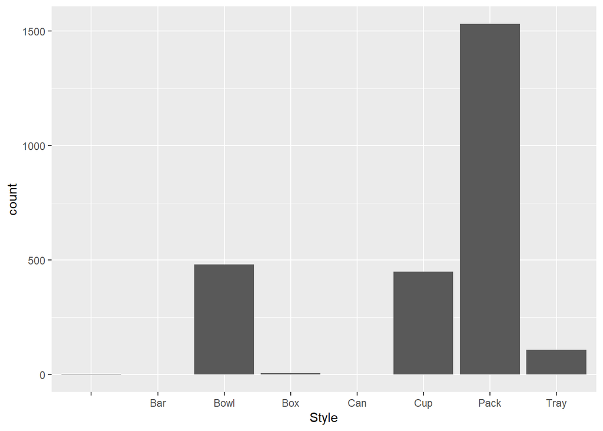

```r
ggplot(ramen,aes(Style)) + geom_bar()
```

The bar graph above shows just how drastic the difference is between the different styles of ramen.

### Find the most popular brand

To determine the most popular brand I will find the brand that received the most five stars.

```r
top_brand <- ramen %>% select(Brand,Stars) %>% group_by(Brand) %>% filter(Stars == 5) %>% count(Brand, sort = TRUE)
head(top_brand) %>% kbl() %>%
  kable_styling()
```

| Brand | n |
| --- | --- |
| Nissin | 76 |
| MyKuali | 22 |
| Nongshim | 19 |
| Indomie | 16 |
| Paldo | 16 |
| Mama | 14 |

The most popular brand is Nissin that received 76 5 star ratings.

## Conclusions

In conclusion the most popular brand is Nissin which received the most five star reviews. Pack is by far the most produced and highly rated style of ramen. Variety was harder to determine but I was able to determine which ones were the most popular by filtering by the top five values and if they were number 1 in Top Ten.

# Superhero TV shows

## Overview

This data set is collected from IMDB.com which and is compiled of superhero tv-shows ratings. [Kaggle Superheroes TV Shows](https://www.kaggle.com/anoopkumarraut/superhero-tv-shows/data) The questions I was asked to answer are below.

Analysis:

1. What is the highest-rated TV show of each year.
2. What is the highest rated TV show from each category in the data set.

```r
tv_csv = "https://raw.githubusercontent.com/moiyajosephs/Data607-Project2/main/Dataset_Superhero-TV-Shows.csv"
tv = read.csv(tv_csv,header=TRUE,sep=",")
summary(tv)
```

```
##   show_title        imdb_rating        release_year         runtime
##  Length:750         Length:750         Length:750         Length:750
##  Class :character   Class :character   Class :character   Class :character
##  Mode  :character   Mode  :character   Mode  :character   Mode  :character
##     genre           parental_guideline  imdb_votes          synopsis
##  Length:750         Length:750         Length:750         Length:750
##  Class :character   Class :character   Class :character   Class :character
##  Mode  :character   Mode  :character   Mode  :character   Mode  :character
```

```r
head(tv) %>% kbl() %>%
  kable_styling()
```

| show_title | imdb_rating | release_year | runtime | genre | parental_guideline | imdb_votes | synopsis |
| --- | --- | --- | --- | --- | --- | --- | --- |
| Peacemaker | 8.5 | 2022- | 40 | Action, Adventure, Comedy | TV-MA | 60,116 | Picking up where The Suicide Squad (2021) left off, Peacemaker returns home after recovering from his encounter with Bloodsport - only to discover that his freedom comes at a price. |
| The Legend of Vox Machina | 8.6 | 2022- | 30 | Animation, Action, Adventure | TV-MA | 13,128 | In a desperate attempt to pay off a mounting bar tab, a band of misfits end up on a quest to save the realm of Exandria from dark, magical forces. |
| Daredevil | 8.6 | 2015-2018 | 54 | Action, Crime, Drama | TV-MA | 4,10,433 | A blind lawyer by day, vigilante by night. Matt Murdock fights the crime of New York as Daredevil. |
| The Boys | 8.7 | 2019- | 60 | Action, Crime, Drama | TV-MA | 3,47,831 | A group of vigilantes set out to take down corrupt superheroes who abuse their superpowers. |
| Raising Dion | 7.2 | 2019- | 50 | Drama, Sci-Fi | TV-G | 13,375 | A widowed single mom discovers that her son has super powers and tries to figure out how to raise him safely and responsibly. |
| Titans | 7.6 | 2018- | 45 | Action, Adventure, Crime | TV-MA | 93,828 | A team of young superheroes combat evil and other perils. |

## Analysis

### What is the highest-rated TV Show of each year?

Some of the television shows release year value is a range instead of a single date. To answer this question, if it is a range I will consider the first year as its release year and the last year indicated as its final year. I will then look for the highest rated show based on a televisions release year.

First I will separate the release year by the - between the release and the final year. Some TV shows have no end year, meaning they are still ongoing.

```r
tv <- tv %>%  separate(release_year, into = c("release", "end"))
head(tv) %>% kbl() %>%
  kable_styling()
```

| show_title | imdb_rating | release | end | runtime | genre | parental_guideline | imdb_votes | synopsis |
| --- | --- | --- | --- | --- | --- | --- | --- | --- |
| Peacemaker | 8.5 | 2022 |  | 40 | Action, Adventure, Comedy | TV-MA | 60,116 | Picking up where The Suicide Squad (2021) left off, Peacemaker returns home after recovering from his encounter with Bloodsport - only to discover that his freedom comes at a price. |
| The Legend of Vox Machina | 8.6 | 2022 |  | 30 | Animation, Action, Adventure | TV-MA | 13,128 | In a desperate attempt to pay off a mounting bar tab, a band of misfits end up on a quest to save the realm of Exandria from dark, magical forces. |
| Daredevil | 8.6 | 2015 | 2018 | 54 | Action, Crime, Drama | TV-MA | 4,10,433 | A blind lawyer by day, vigilante by night. Matt Murdock fights the crime of New York as Daredevil. |
| The Boys | 8.7 | 2019 |  | 60 | Action, Crime, Drama | TV-MA | 3,47,831 | A group of vigilantes set out to take down corrupt superheroes who abuse their superpowers. |
| Raising Dion | 7.2 | 2019 |  | 50 | Drama, Sci-Fi | TV-G | 13,375 | A widowed single mom discovers that her son has super powers and tries to figure out how to raise him safely and responsibly. |
| Titans | 7.6 | 2018 |  | 45 | Action, Adventure, Crime | TV-MA | 93,828 | A team of young superheroes combat evil and other perils. |

IMDB rating and votes are also in the wrong format, so I will change them to number.

```r
tv$imdb_rating <- as.numeric(tv$imdb_rating)
tv$imdb_votes <- as.numeric(tv$imdb_votes)
```

Now that the table is separated, I will group by the release year and find the maximum rating for each.

```r
top_year_show <- tv %>% select(show_title, imdb_rating,release) %>% group_by(release) %>% slice(which.max(imdb_rating))
head(top_year_show) %>% kbl() %>%
  kable_styling()
```

| show_title | imdb_rating | release |
| --- | --- | --- |
| Superman | 7.0 | 1948 |
| The Lone Ranger | 7.7 | 1949 |
| Dick Tracy | 7.6 | 1950 |
| Adventures of Superman | 7.7 | 1952 |
| Commando Cody: Sky Marshal of the Universe | 6.0 | 1953 |
| Captain Midnight | 8.0 | 1954 |

Here I am able to see all the years and the ratings for the top television shows for that year. In 2022, The Legend of Vox Machina was the highest rated television show so far with a score of 8.6.

### What is the highest TV Show from each category in the data set?

The television data set can have many genres, in this data set at least 1 genre is listed. The maximum genres listed is three. I split the list of genres into three separate genres and compared them based on which genre was listed first.

```r
tv <- tv %>%  separate(genre, into = c("genre1", "genre2", "genre3"), sep = ",")
head(tv) %>% kbl() %>%
  kable_styling()
```

| show_title | imdb_rating | release | end | runtime | genre1 | genre2 | genre3 | parental_guideline | imdb_votes | synopsis |
| --- | --- | --- | --- | --- | --- | --- | --- | --- | --- | --- |
| Peacemaker | 8.5 | 2022 |  | 40 | Action | Adventure | Comedy | TV-MA | NA | Picking up where The Suicide Squad (2021) left off, Peacemaker returns home after recovering from his encounter with Bloodsport - only to discover that his freedom comes at a price. |
| The Legend of Vox Machina | 8.6 | 2022 |  | 30 | Animation | Action | Adventure | TV-MA | NA | In a desperate attempt to pay off a mounting bar tab, a band of misfits end up on a quest to save the realm of Exandria from dark, magical forces. |
| Daredevil | 8.6 | 2015 | 2018 | 54 | Action | Crime | Drama | TV-MA | NA | A blind lawyer by day, vigilante by night. Matt Murdock fights the crime of New York as Daredevil. |
| The Boys | 8.7 | 2019 |  | 60 | Action | Crime | Drama | TV-MA | NA | A group of vigilantes set out to take down corrupt superheroes who abuse their superpowers. |
| Raising Dion | 7.2 | 2019 |  | 50 | Drama | Sci-Fi | NA | TV-G | NA | A widowed single mom discovers that her son has super powers and tries to figure out how to raise him safely and responsibly. |
| Titans | 7.6 | 2018 |  | 45 | Action | Adventure | Crime | TV-MA | NA | A team of young superheroes combat evil and other perils. |

```r
tv %>% select(show_title, imdb_rating,genre1) %>% group_by(genre1) %>% slice(which.max(imdb_rating))
```

```
## # A tibble: 14 x 3
## # Groups:   genre1 [14]
##    show_title                   imdb_rating genre1
##    <chr>                              <dbl> <chr>
##  1 The Boys                             8.7 Action
##  2 The Aquabats! Super Show!            8.5 Adventure
##  3 Avatar: The Last Airbender           9.3 Animation
##  4 El ChapulÃn Colorado                 8.5 Comedy
##  5 Constantine                          7.5 Crime
##  6 Marvel Studios: Assembled            8   Documentary
##  7 Dick Tracy                           7.6 Drama
##  8 The Electric Company                 8.1 Family
##  9 Who Wants to Be a Superhero?         6.1 Game-Show
## 10 Werewolf                             8   Horror
## 11 Captain Midnight                     8   Sci-Fi
## 12 Super Power Beat Down                8.3 Short
## 13 Cinema Club                          8.3 Talk-Show
## 14 The Lone Ranger                      7.7 Western
```

```r
tv %>% kbl() %>%
  kable_styling()
```

[output not shown]

[output cut: 720 more lines]

When considering the first genre, each genre is listed separately with the highest rated television show and rating. The genre with the highest rating is *Avatar the Last Airbender*, which is an animation that received a score of 9.3.

```r
tv %>% select(show_title, imdb_rating,genre2) %>% group_by(genre2) %>% slice(which.max(imdb_rating)) %>% kbl() %>%
  kable_styling()
```

| show_title | imdb_rating | genre2 |
| --- | --- | --- |
| Avatar: The Last Airbender | 9.3 | Action |
| Journey to the West | 8.7 | Adventure |
| Mazinger Z | 7.8 | Animation |
| The Aquabats! Super Show! | 8.5 | Comedy |
| The Boys | 8.7 | Crime |
| Darna | 8.6 | Drama |
| El ChapulÃn Colorado | 8.5 | Family |
| Garo | 7.8 | Fantasy |
| Bridal Mask | 8.4 | History |
| The New Avengers | 7.2 | Mystery |
| Who Wants to Be a Superhero? | 6.1 | Reality-TV |
| He & She | 8.0 | Romance |
| Captain Vyom | 8.4 | Sci-Fi |
| Megas XLR | 8.2 | Short |
| Werewolf | 8.0 | Thriller |
| Zorro | 8.2 | Western |
| Super Power Beat Down | 8.3 | NA |

```r
tv %>% select(show_title, imdb_rating,genre3) %>% group_by(genre3) %>% slice(which.max(imdb_rating)) %>% kbl() %>%
  kable_styling()
```

| show_title | imdb_rating | genre3 |
| --- | --- | --- |
| Megas XLR | 8.2 | Action |
| Avatar: The Last Airbender | 9.3 | Adventure |
| Ultimate Muscle: The Kinnikuman Legacy | 7.6 | Animation |
| One Punch Man | 8.7 | Comedy |
| Ghost in the Shell: Stand Alone Complex | 8.5 | Crime |
| The Boys | 8.7 | Drama |
| The Aquabats! Super Show! | 8.5 | Family |
| Darna | 8.6 | Fantasy |
| Garo | 7.8 | Horror |
| Stingray | 7.5 | Mystery |
| Drawn Together | 7.0 | Reality-TV |
| Bridal Mask | 8.4 | Romance |
| Exosquad | 8.4 | Sci-Fi |
| Action Man | 6.7 | Sport |
| The Champions | 7.6 | Thriller |
| Kung Fu | 7.7 | Western |
| Journey to the West | 8.7 | NA |

```r
summary(tv)
```

```
##   show_title         imdb_rating      release              end
##  Length:750         Min.   :2.000   Length:750         Length:750
##  Class :character   1st Qu.:6.500   Class :character   Class :character
##  Mode  :character   Median :7.100   Mode  :character   Mode  :character
##                     Mean   :7.012
##                     3rd Qu.:7.700
##                     Max.   :9.300
##                     NA's   :36
##    runtime             genre1             genre2             genre3
##  Length:750         Length:750         Length:750         Length:750
##  Class :character   Class :character   Class :character   Class :character
##  Mode  :character   Mode  :character   Mode  :character   Mode  :character
##
##
##
##
##  parental_guideline   imdb_votes      synopsis
##  Length:750         Min.   : 14.0   Length:750
##  Class :character   1st Qu.:204.5   Class :character
##  Mode  :character   Median :388.0   Mode  :character
##                     Mean   :432.8
##                     3rd Qu.:652.5
##                     Max.   :993.0
##                     NA's   :483
```

## Conclusion

Action and Adventure are the most popular genres which makes sense considering it is a dataset of superhero TV shows. Superhero TV shows have always been popular with the eldest TV show coming from 1948. A summary function of the cleaned up data set shows the average IMDB rating for television shows are 7.012. There are also 36 missing values. The maximum is 9.3 and the minimum is 2. For the amount of votes per show, the mean value is 432.8, and the amount of missing values are 483.

# Food Scrap Drop-Off Locations in NYC | NYC Open Data

## Overview

This data set was taken from [Food Scrap Drop-Off Locations in NYC](https://data.cityofnewyork.us/Environment/Food-Scrap-Drop-Off-Locations-in-NYC/if26-z6xq). It is a collection of data describing locations where NYC residents can drop off their food scraps to be composted. My classmate suggested some questions for analysis and I chose these ones to answer:

1. Which Council Districts have the most drop-offs?
2. What do those have in common?
3. How many are open year round?
4. What do those have in common?
5. Do any Community Districts have more then one drop-off?
6. Which borough has the most drop-offs?

```r
food_scrap_csv <- "https://raw.githubusercontent.com/moiyajosephs/Data607-Project2/main/Food_Scrap_Drop-Off_Locations_in_NYC.csv"
food_scrap <- read.csv(food_scrap_csv,header=TRUE, sep=",")
head(food_scrap)
```

```
##         Borough CouncilDist                    Food_Scrap_Drop_Off_Site_Name
## 1        Queens          29 Forest Hills Green Team Hosted by MacDonald Park
## 2         Bronx          14            Kingsbridge Heights Community Center:
## 3        Queens          22                             Astoria Pug: Newtown
## 4     Manhattan           3                                8th Ave & 23rd St
## 5 Staten Island          51                   Staten Island Mall Greenmarket
## 6      Brooklyn          38                  Los ColibrÃes Community Garden
##   Latitude
## 1 40.72222
## 2 40.87730
## 3 40.76267
## 4 40.74533
## 5 40.58376
## 6 40.65473
##                                                                               Location
```

[output cut: 48 more lines]

```r
summary(food_scrap)
```

```
##    Borough           CouncilDist    Food_Scrap_Drop_Off_Site_Name
##  Length:152         Min.   : 1.00   Length:152
##  Class :character   1st Qu.: 7.00   Class :character
##  Mode  :character   Median :22.00   Mode  :character
##                     Mean   :21.45
##                     3rd Qu.:35.00
##                     Max.   :51.00
##     Latitude       Location           Longitude        NTAName
##  Min.   :40.58   Length:152         Min.   :-74.16   Length:152
##  1st Qu.:40.68   Class :character   1st Qu.:-73.99   Class :character
##  Median :40.73   Mode  :character   Median :-73.94   Mode  :character
##  Mean   :40.74                      Mean   :-73.94
##  3rd Qu.:40.78                      3rd Qu.:-73.90
##  Max.   :40.90                      Max.   :-73.72
##     Notes             Object.ID      Operation_Day_Hours Open_Months
##  Length:152         Min.   :  1.00   Length:152          Length:152
##  Class :character   1st Qu.: 38.75   Class :character    Class :character
##  Mode  :character   Median : 76.50   Mode  :character    Mode  :character
##                     Mean   : 76.50
##                     3rd Qu.:114.25
##                     Max.   :152.00
##   Hosted_By           Website              boroCD          ct2010
##  Length:152         Length:152         Min.   :101.0   Min.   :   100
##  Class :character   Class :character   1st Qu.:109.0   1st Qu.:  7875
##  Mode  :character   Mode  :character   Median :301.5   Median : 19350
##                                        Mean   :260.9   Mean   : 28141
##                                        3rd Qu.:401.0   3rd Qu.: 37100
##                                        Max.   :502.0   Max.   :156700
##     point              Precinct
##  Length:152         Min.   :  1.00
##  Class :character   1st Qu.: 27.25
##  Mode  :character   Median : 67.50
##                     Mean   : 62.57
##                     3rd Qu.:104.25
##                     Max.   :122.00
```

## Analysis

### Which Council Districts have the most drop-offs? What do they have in common?

```r
# ramen %>% select(Brand,Stars) %>% group_by(Brand) %>% filter(Stars == 5) %>% count(Brand, sort = TRUE)
council_district <- food_scrap %>% select(Borough,CouncilDist) %>% group_by(Borough) %>%  count(CouncilDist, sort = TRUE)
head(council_district) %>% kbl() %>%
  kable_styling()
```

| Borough | CouncilDist | n |
| --- | --- | --- |
| Manhattan | 3 | 14 |
| Manhattan | 1 | 9 |
| Queens | 26 | 9 |
| Bronx | 11 | 7 |
| Bronx | 17 | 7 |
| Queens | 22 | 7 |

The council districts that have the most drop-offs the council district 3(Manhattan). The council district 1(Manhattan) and Queens are tied with 9 food scrap drop offs. There doesn’t seem to be any correlation between the top districts other than the food that they do not accept for scraps (no meat, dairy or bones).

### How many are open year round? What do those have in common?

```r
food_scrap %>% count(Open_Months, sort=TRUE) %>% kbl() %>%
  kable_styling()
```

| Open_Months | n |
| --- | --- |
| Year Round | 119 |
| April-October | 3 |
| April - November | 2 |
| April - October | 2 |
| May 1 - November 1 | 2 |
| Year-Round | 2 |
| April-November | 1 |
| April - December | 1 |
| April - January | 1 |
| Everyday | 1 |
| July- November 17, 2020 | 1 |
| July 14th - November 24th | 1 |
| June - November | 1 |
| June - October | 1 |
| June 25 - November 19 | 1 |
| June13 - November 14 | 1 |
| March - November | 1 |
| May - November | 1 |
| May 1- November 1 | 1 |
| May 1 - December 3 | 1 |
| mid-March - end of January | 1 |
| Seasonal (closing Dec 18) | 1 |
| Seasonal, April-October | 1 |
| Seasonal, April - November 22 | 1 |
| Seasonal, May-November | 1 |
| Yea Round | 1 |
| Year Round (except February) | 1 |
| Year Round (Except February) | 1 |

Just counting each occurrence of the Open Months column would not be enough to find the year round food scrap drop offs. “Year Round” as a string has not been entered the same way throughout the dataset, so instead I will look for any occurrence that has the word Year in it.

```r
food_scrap %>% count(Open_Months, sort=TRUE) %>% filter(str_detect(Open_Months, "Year")) %>% kbl() %>%
  kable_styling()
```

| Open_Months | n |
| --- | --- |
| Year Round | 119 |
| Year-Round | 2 |
| Year Round (except February) | 1 |
| Year Round (Except February) | 1 |

By filtering this way I can see there are 123 year round food scrap drop offs throughout NYC. (Technically the Everyday value also counts as Year Round.)

### Do any Community Districts have more then one drop-off?

```r
food_scrap  %>% count(boroCD, sort=TRUE) %>% kbl() %>% kable_styling()
```

| boroCD | n |
| --- | --- |
| 401 | 10 |
| 101 | 8 |
| 104 | 8 |
| 102 | 6 |
| 103 | 6 |
| 206 | 6 |
| 308 | 6 |
| 402 | 6 |
| 301 | 5 |
| 501 | 5 |
| 110 | 4 |
| 208 | 4 |
| 316 | 4 |
| 413 | 4 |
| 106 | 3 |
| 109 | 3 |
| 111 | 3 |
| 204 | 3 |
| 207 | 3 |
| 306 | 3 |
| 307 | 3 |
| 107 | 2 |
| 108 | 2 |
| 201 | 2 |
| 302 | 2 |
| 303 | 2 |
| 304 | 2 |
| 314 | 2 |
| 403 | 2 |
| 406 | 2 |
| 408 | 2 |
| 412 | 2 |
| 502 | 2 |
| 105 | 1 |
| 112 | 1 |
| 202 | 1 |
| 203 | 1 |
| 209 | 1 |
| 210 | 1 |
| 211 | 1 |
| 212 | 1 |
| 305 | 1 |
| 309 | 1 |
| 310 | 1 |
| 311 | 1 |
| 312 | 1 |
| 313 | 1 |
| 315 | 1 |
| 317 | 1 |
| 318 | 1 |
| 355 | 1 |
| 404 | 1 |
| 405 | 1 |
| 407 | 1 |
| 409 | 1 |
| 410 | 1 |
| 411 | 1 |
| 414 | 1 |

Many community districts have more than one drop off. Below is the community district, 401, which had ten drop off centers.

```r
food_scrap %>% filter(boroCD == 401) %>% kbl() %>% kable_styling()
```

| Borough | CouncilDist | Food_Scrap_Drop_Off_Site_Name | Latitude | Location | Longitude | NTAName | Notes | Object.ID | Operation_Day_Hours | Open_Months | Hosted_By | Website | boroCD | ct2010 | point | Precinct |
| --- | --- | --- | --- | --- | --- | --- | --- | --- | --- | --- | --- | --- | --- | --- | --- | --- |
| Queens | 22 | Astoria Pug: Newtown | 40.76267 | 30-36 41st Street, Astoria, NY | -73.91511 | Astoria | Not accepted: meat, bones, or dairy | 14 | Fridays 10:00AM - 4:30PM | Year Round | Astoria Pug | https://www.instagram.com/astoriapug/?hl=en | 401 | 14900 | POINT (-73.915111 40.762667) | 114 |
| Queens | 22 | Hellgate Farm | 40.76903 | 14-33 30th Drive, Long Island City, NY 11102 | -73.92983 | Old Astoria |  | 10 | December-February: Saturdays & Sundays, 08:00 AM-08:00 PM; | Year Round | Staff at Hellgate Farm | https://www.hellgatefarm.com/ | 401 | 7900 | POINT (-73.92982649999993 40.76903240000007) | 114 |
| Queens | 26 | Commuter Composting at 21 St-Queensbridge F | 40.75369 | NW Corner of 21st street at 41st Ave | -73.94228 | Queensbridge-Ravenswood-Long Island City | Not accepted: meat, bones, or dairy | 19 | Tuesdays 8:00AM - 11:00AM | Year Round | NYC Compost Project Hosted by Big Reuse |  | 401 | 3300 | POINT (-73.94228379999998 40.75368580000003) | 114 |
| Queens | 22 | Astoria Pug: Ditmars | 40.77419 | Ditmars #1 Municipal Parking Field 22-18 33rd Street | -73.91161 | Steinway | Not accepted: meat, bones, dairy, or oil. | 15 | Saturdays 9:00AM - 3:45PM | Year Round | Astoria Pug | https://www.instagram.com/astoriapug/?hl=en | 401 | 11500 | POINT (-73.911611 40.774194) | 114 |
| Queens | 22 | Astoria Pug: Broadway | 40.76147 | 32-11 31st St, Queens, NY 11106 | -73.92561 | Astoria | Not accepted: meat, bones, dairy, or oil | 11 | Saturdays 9:00AM - 3:00PM | Year Round | Astoria Pug | https://www.instagram.com/astoriapug/?hl=en | 401 | 5900 | POINT (-73.925611 40.761472) | 114 |
| Queens | 26 | Socrates Sculpture Park | 40.76839 | Broadway & Vernon Blvd, Queens, NY 11106 | -73.93700 | Queensbridge-Ravenswood-Long Island City | Not accepted: meat, bones, dairy, or oil | 18 | Every day 9:00AM - dusk | Year Round | Socrates Sculpture Park | socratessculpturepark.org | 401 | 3700 | POINT (-73.937 40.768389) | 114 |
| Queens | 22 | Astoria Pug: Most Precious Blood | 40.75914 | 32-23 36th St, Queens, NY 11106 | -73.92146 | Astoria | Not accepted: meat, bones, dairy, or oil | 12 | 24/7 | Year Round | Astoria Pug | https://www.instagram.com/astoriapug/?hl=en | 401 | 5900 | POINT (-73.92146 40.75914) | 114 |
| Queens | 26 | Moore-Jackson Cemetery/Garden | 40.75615 | 31-61 51st St, Woodside, NY 11377 | -73.90792 | Woodside | Not accepted: meat, bones, or dairy | 17 | Saturdays 9:00AM - 12:00PM | Year Round | Members at Moore-Jackson Garden | https://www.facebook.com/MooreJacksonNYC/ | 401 | 29500 | POINT (-73.907915 40.75614900000001) | 114 |
| Queens | 22 | Astoria Pug: Steinway | 40.76406 | 38-12 30th Ave, Queens, NY 11103 | -73.91572 | Astoria | Not accepted: meat, bones, dairy, or oil | 13 | 24/7 | Year Round | Astoria Pug | https://www.instagram.com/astoriapug/?hl=en | 401 | 15500 | POINT (-73.915722 40.764056) | 114 |
| Queens | 22 | Astoria Pug: Hoyt | 40.77538 | Northwest corner of Hoyt Avenue North and 21st Street, in a courtyard that?s officially called SITTING AREA | -73.92302 | Steinway | Not accepted: meat, bones, or dairy | 16 | Saturdays 9:00AM - 3:00PM | Year Round | Astoria Pug | https://www.instagram.com/astoriapug/?hl=en | 401 | 9500 | POINT (-73.92302 40.77538) | 114 |

By filtering by the community district I can see that it is in Astoria, Queens. All listed in this dataset do year long drop offs.

### Which borough has the most drop-offs?

```r
food_scrap %>% count(Borough, sort = TRUE) %>% kbl() %>% kable_styling()
```

| Borough | n |
| --- | --- |
| Manhattan | 46 |
| Brooklyn | 38 |
| Queens | 35 |
| Bronx | 24 |
| Staten Island | 7 |
| Brookyln | 1 |
| Greenwich St. & Duane St | 1 |

Greenwich value is actually in Manhattan and a mistake in the data set itself. Meaning that Manhattan has 47 drop off centers. Brooklyn has 38, and Queens has 35.

## Conclusion

In conclusion, there are 152 drop off locations located throughout New York City. Manhattan has the most food scrap drop off locations and most offer year round drop off. Possible further analysis would be to see which one gets the most donations.